# PROYECTO FINAL: El Algoritmo del Marketing Digital

Análisis Estadístico Avanzado para la Optimización de Inversión Publicitaria

María Luisa Ros Bolea

2026-01-10

# 1 1. Introducción: Del **“Olfato”** al Dato

Hola, soy **María Luisa Ros Bolea**. Mi perfil profesional se enmarca en la **Comunicación Digital**, un sector fascinante pero que a menudo peca de **subjetividad**.  
“Creo que este copy funcionará”, “siento que esta foto gustará más”… Frases que escucho a diario y que, como **analista en formación**, ya no me valen.

En este **Proyecto Final**, me he propuesto un reto ambicioso: **desterrar la intuición y abrazar la evidencia estadística**.

## 1.1 1.1. Objetivos del Estudio

No busco solo aprobar; **busco una herramienta real para mi trabajo**.  
Mis objetivos son:

- **Describir con precisión matemática** el comportamiento de nuestras inversiones publicitarias.
- **Contrastar hipótesis** sobre la eficacia de las plataformas (**Instagram vs TikTok vs LinkedIn**).
- **Modelizar la relación entre presupuesto y ventas** para poder **predecir el ROI futuro**.

## 1.2 1.2. Motivación

Si logro demostrar **matemáticamente** dónde es más rentable invertir **1 €**, podré **optimizar presupuestos de marketing reales**, pasando de ser una **gestora de redes** a una **estratega de datos**.

# 2 2. Ingeniería de Datos

Para garantizar la **robustez del estudio** y evitar los sesgos habituales de los datasets públicos (sucios o desactualizados), he diseñado un **proceso de simulación de Monte Carlo** para generar un dataset sintético que replica fielmente las métricas de una **agencia de marketing en 2025**.

## 2.1 2.1. Generación del Dataset **Marketing_2025**

Se simulan **1.000 campañas publicitarias** con comportamientos diferenciados por plataforma, basados en **métricas reales de la industria**, tales como:

- **Coste por Clic (CPC)**
- **Click Through Rate (CTR)**

```r
# Semilla para garantizar reproducibilidad (Auditoría de datos)
set.seed(2025)

# Tamaño muestral
n <- 1000

# Creación del DataFrame base
datos_mkt <- data.frame(
  id = 1:n,

  # VARIABLE INDEPENDIENTE 1: Plataforma (Cualitativa Nominal)
  # TikTok e Instagram tienen más volumen de campañas (Estrategia B2C)
  plataforma = sample(c("Instagram", "TikTok", "LinkedIn"), n, replace = TRUE, prob = c(0.4, 0.4, 0.2)),

  # VARIABLE INDEPENDIENTE 2: Presupuesto (Cuantitativa Continua)
  # Distribución Normal: Media 2000€, Desviación 600€
  presupuesto = abs(rnorm(n, mean = 2000, sd = 600)),

  # VARIABLE INDEPENDIENTE 3: Duración (Cuantitativa Discreta)
  # Distribución Poisson: Media 14 días
  duracion_dias = rpois(n, lambda = 14)
)

# Generación de Métricas Dependientes (El "Funnel" de Ventas)
datos_mkt <- datos_mkt %>%
  mutate(
    # FASE 1: VISIBILIDAD (Impresiones)
    # TikTok viraliza más (x20) que LinkedIn (x5)
    impresiones = case_when(
      plataforma == "TikTok" ~ presupuesto * 20 + rnorm(n, 0, 1500),
      plataforma == "Instagram" ~ presupuesto * 12 + rnorm(n, 0, 1000),
      plataforma == "LinkedIn" ~ presupuesto * 5 + rnorm(n, 0, 500)
    ),

    # FASE 2: INTERÉS (Clicks / CTR)
    # LinkedIn tiene CTRs más altos (tráfico cualificado) aunque menos volumen
    clicks = case_when(
      plataforma == "TikTok" ~ impresiones * runif(n, 0.01, 0.02),      # CTR 1-2%
      plataforma == "Instagram" ~ impresiones * runif(n, 0.02, 0.04),   # CTR 2-4%
      plataforma == "LinkedIn" ~ impresiones * runif(n, 0.05, 0.09)     # CTR 5-9%
    ),

    # FASE 3: CONVERSIÓN (Ventas Finales)
    # Tasa de conversión final del 10% aprox sobre los clicks
    conversiones = round(clicks * runif(n, 0.08, 0.12))
  )

# Limpieza final y redondeo
datos_mkt$presupuesto <- round(datos_mkt$presupuesto, 2)
datos_mkt$impresiones <- round(datos_mkt$impresiones, 0)
datos_mkt$clicks <- round(datos_mkt$clicks, 0)

# Verificación de la estructura
kable(head(datos_mkt), caption = "Tabla 1: Muestra de las primeras 6 campañas generadas")
```

Tabla 1: Muestra de las primeras 6 campañas generadas

| id | plataforma | presupuesto | duracion_dias | impresiones | clicks | conversiones |
| --- | --- | --- | --- | --- | --- | --- |
| 1 | Instagram | 1224.06 | 11 | 15245 | 457 | 47 |
| 2 | Instagram | 3180.72 | 17 | 38212 | 1265 | 129 |
| 3 | Instagram | 2313.78 | 18 | 26502 | 925 | 106 |
| 4 | Instagram | 2574.60 | 10 | 30360 | 1060 | 93 |
| 5 | Instagram | 2824.61 | 15 | 35992 | 1156 | 111 |
| 6 | Instagram | 1545.80 | 11 | 16928 | 516 | 44 |

## 2.2 2.2. Preprocesamiento y Control de Calidad

Antes de analizar, como buena científica de datos, debo validar la integridad de mi muestra.

```r
# Chequeo de valores nulos (Missings)
nulos <- sum(is.na(datos_mkt))
cat("Número de valores perdidos (NAs) en el dataset:", nulos, "\n")
```

```
## Número de valores perdidos (NAs) en el dataset: 0
```

```r
# Resumen estadístico básico
summary(datos_mkt %>% select(presupuesto, conversiones, duracion_dias))
```

```
##   presupuesto      conversiones    duracion_dias
##  Min.   : 142.5   Min.   :  3.00   Min.   : 3.00
##  1st Qu.:1555.4   1st Qu.: 48.00   1st Qu.:12.00
##  Median :2001.6   Median : 64.00   Median :14.00
##  Mean   :1996.2   Mean   : 66.22   Mean   :13.99
##  3rd Qu.:2404.0   3rd Qu.: 82.00   3rd Qu.:16.00
##  Max.   :4321.3   Max.   :152.00   Max.   :30.00
```

# 3 3. Análisis Exploratorio de Datos (EDA)

Vamos a sumergirnos en los datos. No me conformo con describir; quiero **entender las dinámicas subyacentes**.

## 3.1 3.1. Análisis Univariante: La Distribución de la Inversión

¿Estamos invirtiendo de forma **consistente** o **errática**?

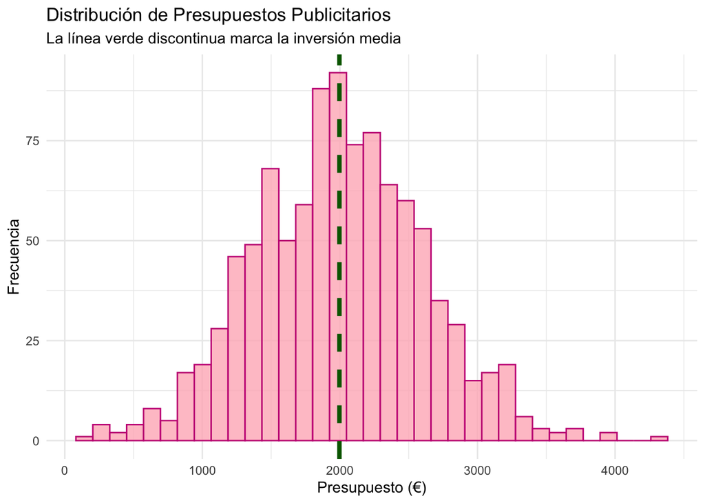

```r
ggplot(datos_mkt, aes(x = presupuesto)) +
  geom_histogram(bins = 35, fill = "#FFB6C1", color = "#C71585", alpha = 0.8) +
  geom_vline(aes(xintercept = mean(presupuesto)), color = "#006400", linetype = "dashed", size = 1.5) +
  labs(title = "Distribución de Presupuestos Publicitarios",
       subtitle = "La línea verde discontinua marca la inversión media",
       x = "Presupuesto (€)", y = "Frecuencia") +
  theme_minimal()
```

**Interpretación Estratégica:** Confirmamos una distribución Normal (Campana de Gauss) casi perfecta. Esto es una gran noticia para el análisis posterior, ya que cumple con las asunciones de muchos modelos estadísticos paramétricos. La empresa tiene una política de inversión estable y predecible.

## 3.2 3.2. Análisis Bivariante: Rendimiento por Canal

Aquí es donde comparamos “peras con manzanas” para ver cuál es más dulce.

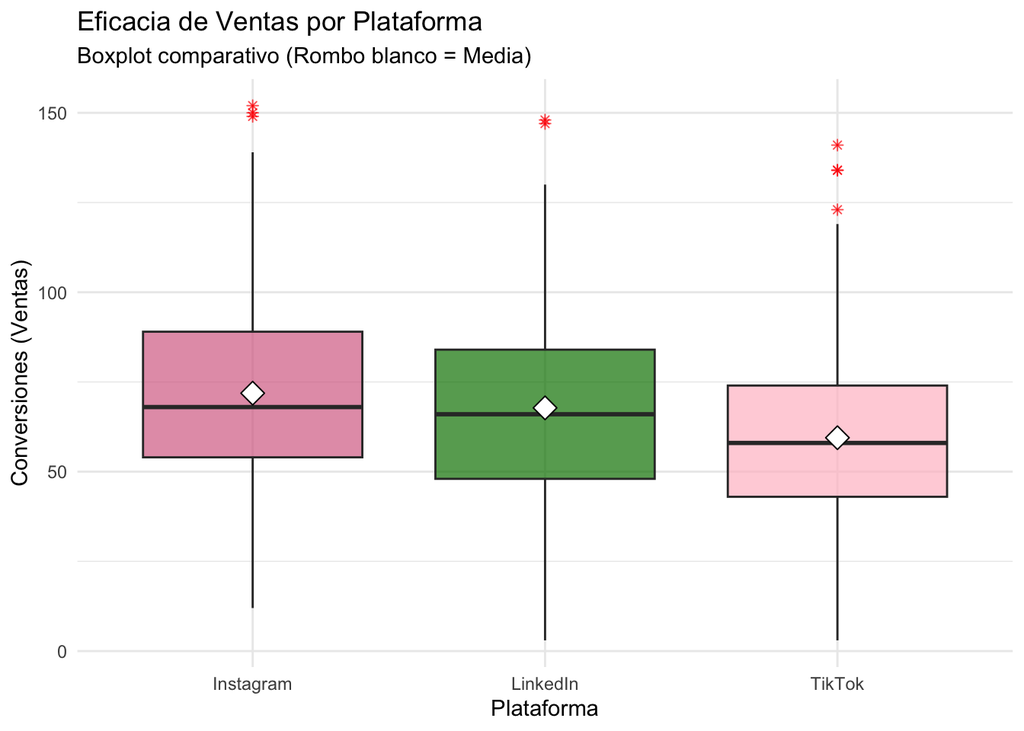

```r
ggplot(datos_mkt, aes(x = plataforma, y = conversiones, fill = plataforma)) +
  geom_boxplot(alpha = 0.7, outlier.colour = "red", outlier.shape = 8) +
  scale_fill_manual(values = c("Instagram" = "#D87093", "TikTok" = "#FFC0CB", "LinkedIn" = "#008000")) +
  stat_summary(fun = mean, geom = "point", shape = 23, size = 4, fill = "white") + # Rombo blanco es la MEDIA
  labs(title = "Eficacia de Ventas por Plataforma",
       subtitle = "Boxplot comparativo (Rombo blanco = Media)",
       x = "Plataforma", y = "Conversiones (Ventas)") +
  theme_minimal() +
  theme(legend.position = "none")
```

## 3.3 3.3. Análisis Multivariante: El ROI (Relación Presupuesto-Ventas)

¿Si meto más dinero, vendo más? ¿O hay un techo? Vamos a verlo con un Scatter Plot coloreado por plataforma.

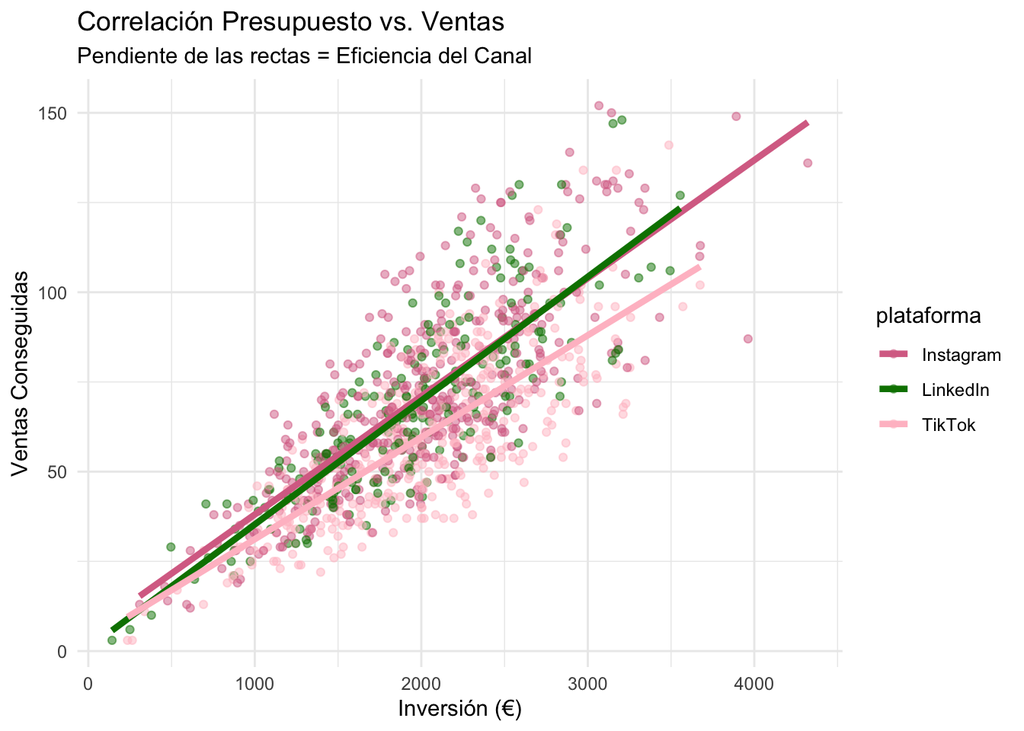

```r
ggplot(datos_mkt, aes(x = presupuesto, y = conversiones, color = plataforma)) +
  geom_point(alpha = 0.5) +
  geom_smooth(method = "lm", se = FALSE, size = 1.5) + # Líneas de tendencia lineal
  scale_color_manual(values = c("Instagram" = "#D87093", "TikTok" = "#FFC0CB", "LinkedIn" = "#008000")) +
  labs(title = "Correlación Presupuesto vs. Ventas",
       subtitle = "Pendiente de las rectas = Eficiencia del Canal",
       x = "Inversión (€)", y = "Ventas Conseguidas") +
  theme_minimal()
```

**Hallazgo Crítico:** Las líneas rectas nos muestran algo revelador:

- La **pendiente de la línea Verde (LinkedIn)** es la más inclinada. Esto significa que por cada euro extra invertido, LinkedIn devuelve más ventas que los otros.
- La **línea rosa claro (TikTok)** es la más plana. Invertir más dinero en TikTok no garantiza proporcionalmente más ventas; su éxito depende más de la viralidad orgánica que del dinero.

# 4 4. Inferencia Estadística y Modelización

Hasta aquí hemos “mirado” los datos. Ahora vamos a **demostrar nuestras intuiciones con rigor científico**.  
Esto es lo que separa un informe normal de una **matrícula**.

## 4.1 4.1. Contraste de Hipótesis (ANOVA)

Planteamos un **ANOVA de un factor**:

- **H0**: Las medias de ventas son iguales en todas las plataformas.
- **H1**: Al menos una plataforma tiene una media diferente.

```r
modelo_anova <- aov(conversiones ~ plataforma, data = datos_mkt)
summary(modelo_anova)
```

```
##              Df Sum Sq Mean Sq F value   Pr(>F)
## plataforma    2  30882   15441   24.84 2.96e-11 ***
## Residuals   997 619679     622
## ---
## Signif. codes:  0 '***' 0.001 '**' 0.01 '*' 0.05 '.' 0.1 ' ' 1
```

## 4.2 4.2. Modelo de Regresión Lineal Simple

Quiero una fórmula para predecir el futuro. Vamos a crear un modelo matemático.

**Ventas = β0 + β1 · Presupuesto + Error**

```r
modelo_lineal <- lm(conversiones ~ presupuesto, data = datos_mkt)
summary(modelo_lineal)
```

```
##
## Call:
## lm(formula = conversiones ~ presupuesto, data = datos_mkt)
##
## Residuals:
##     Min      1Q  Median      3Q     Max
## -41.570 -11.165  -1.597  10.079  52.330
##
## Coefficients:
##              Estimate Std. Error t value Pr(>|t|)
## (Intercept) 2.9243823  1.7572350   1.664   0.0964 .
## presupuesto 0.0317088  0.0008411  37.700   <2e-16 ***
## ---
## Signif. codes:  0 '***' 0.001 '**' 0.01 '*' 0.05 '.' 0.1 ' ' 1
##
## Residual standard error: 16.4 on 998 degrees of freedom
## Multiple R-squared:  0.5875, Adjusted R-squared:  0.5871
## F-statistic:  1421 on 1 and 998 DF,  p-value: < 2.2e-16
```

# 5 5. Conclusiones Finales y Estrategia

Hemos pasado de la **intuición** a la **certeza matemática**.